# Course Project Practical Machine Learning

Renée Jansen

20 April 2017

### Data

This project has been based on the research “Qualitative Activity Recognition of Weight Lifting Exercises”. More information about the data, as well as the overall original project, can be found in this paper: http://groupware.les.inf.puc-rio.br/public/papers/2013.Velloso.QAR-WLE.pdf

The goal of this project is to predict the manner in which someone performed a fitness exercise. The manner in which the exercise is performed can be classified into classes A to E. Class A means that someone performed the exercise exactly according to the specification, while class B to E indicate varying mistakes someone might have made. The data that have been used to build this model consist of output from sensors that were attached to the person’s body and their dumbbell while performing this exercise: accelerometers were placed on the belt, forearm, arm, and dumbell of 6 participants.

```r
library(caret)
library(parallel)
library(doParallel)
```

### Data Preparation & EDA

For this project, we have used the caret-package to train and test our model.

The data contained NA-values, as well as blank spaces and #DIV/0! values. In loading the data into R, we have set all of these values to be N/A in order to make processing of the data easier.

```r
data <- read.csv("C:/Users/Renee/Desktop/Studie/Machine Learning/CourseProject/pml-training.csv", na.strings = c("", "NA", "#DIV/0!"))

set.seed(666)
inTrain <- createDataPartition(y = data$classe, p = 0.6, list = FALSE)
testing <- data[-inTrain, ]
training <- data[inTrain, ]
```

Using a for-loop to count the NA’s per variable, we have found a large part of the features (100 out of 160) consist for almost 98% of NA’s. As these features only provide information about a very limited part of the observation, we have deemed them to be uninformative and excluded them from the dataset going forward. This leaves us with a dataset of 60 variables, containing no NA’s at all.

Furthermore, we have removed the first 7 variables from the dataset, which contain information like username, date, and timestamp. As we are looking to predict class from sensor data, these 7 variables will not contribute to our model in a meaningful way.

```r
data_NA <- data.frame()

for (i in 1:ncol(training)) {
        NAcount <- (sum(is.na(training[,i])) / nrow(training))
        data_NA <- rbind(data_NA, NAcount)
}

sum(data_NA)
```

```
## [1] 98.03626
```

```r
dataselect <- data_NA == 0
training <- training[,dataselect]
sum(is.na(training))
```

```
## [1] 0
```

```r
training <- training[,-c(1:7)]
```

To get a better look at our outcome variable, “classe”, we have made a simple bar plot and table, which reveals that while class “A” is the most common in this dataset, the division between the five classes is pretty equal. Each class separately has a large enough amount of observations in order to be included in the model.

```r
summary(training$classe)
```

```
##    A    B    C    D    E
## 3348 2279 2054 1930 2165
```

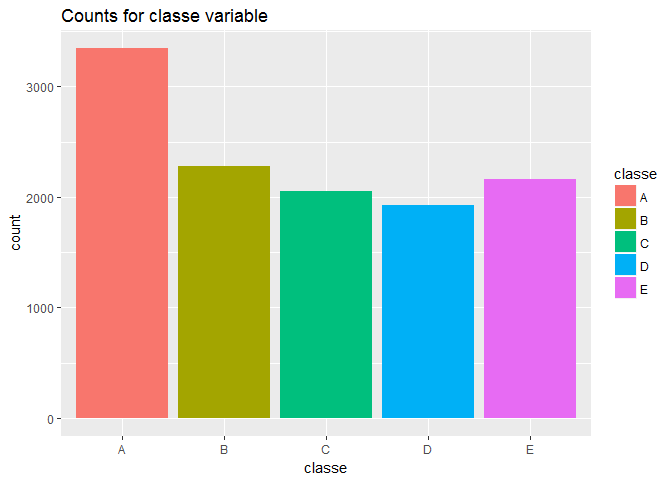

```r
ggplot(data = training, aes(x = classe), fill = classe) + geom_bar(aes(fill = classe)) + labs(title = "Counts for classe variable")
```

### Model Selection

Before training our models, we have configured R to allow for parallel processing (see https://github.com/lgreski/datasciencectacontent/blob/master/markdown/pml-randomForestPerformance.md).

```r
cluster <- makeCluster(detectCores()-1)
registerDoParallel(cluster)
```

As we are facing a classification problem, and our goal is to predict “class” from sensor data as accurately as possible, we have decided to fit a Random-Forest model. Even if the results from such a model will not be the most simple or interpretable, we expect model predictions to be highly accurate for this classification problem.

```r
fitControl <- trainControl(method = "cv", number = 5, allowParallel = TRUE)
outcome <- training[,53]
predictors <- training[,-53]

RFmdl3 <- train(predictors, outcome, data = training, method = "rf", ntree = 200, trControl = fitControl)
RFmdl3
```

```
## Random Forest
##
## 11776 samples
##    52 predictor
##     5 classes: 'A', 'B', 'C', 'D', 'E'
##
## No pre-processing
## Resampling: Cross-Validated (5 fold)
## Summary of sample sizes: 9421, 9421, 9421, 9421, 9420
## Resampling results across tuning parameters:
##
##   mtry  Accuracy   Kappa
##    2    0.9881964  0.9850668
##   27    0.9886210  0.9856046
##   52    0.9789406  0.9733572
##
## Accuracy was used to select the optimal model using  the largest value.
## The final value used for the model was mtry = 27.
```

```r
RFmdl3$finalModel
```

```
##
## Call:
##  randomForest(x = x, y = y, ntree = 200, mtry = param$mtry, data = ..1)
##                Type of random forest: classification
##                      Number of trees: 200
## No. of variables tried at each split: 27
##
##         OOB estimate of  error rate: 0.91%
## Confusion matrix:
##      A    B    C    D    E class.error
## A 3340    5    2    0    1 0.002389486
## B   22 2248    7    2    0 0.013602457
## C    0   13 2031   10    0 0.011197663
## D    0    2   24 1899    5 0.016062176
## E    0    2    4    8 2151 0.006466513
```

```r
stopCluster(cluster)
registerDoSEQ()

varImp <- varImp(RFmdl3)$importance
head(varImp[order(varImp, decreasing = TRUE), , drop = FALSE])
```

```
##                     Overall
## roll_belt         100.00000
## pitch_forearm      61.28480
## yaw_belt           53.66787
## magnet_dumbbell_z  46.92169
## pitch_belt         45.57561
## magnet_dumbbell_y  44.50743
```

### Testing Model Performance

We then used the test-set we have created above to double-check if our model performs as estimated. First, we have made the same adjustments to the data in our testing set as we did for the training set (removing variables with almost 98% NA, removing first 7 variables). Using our random forest model, we have made predictions for our test data set. The confusionmatrix we then created based on our predictions and the actual ‘classe’ variable in the testing part of our dataset gave an accuracy of 99.15 on the test data set. This means we expect the out of sample error rate to be about 1-0.9915 = 0.0085 or 0.85%.

```r
testing_comp <- testing[,dataselect]
testing <- testing_comp[,-c(1:7)]
pred <- predict(RFmdl3, testing[,-53])
confusionMatrix(pred, testing$classe)
```

```
## Confusion Matrix and Statistics
##
##           Reference
## Prediction    A    B    C    D    E
##          A 2231   14    0    1    0
##          B    1 1497   20    0    1
##          C    0    7 1345   15    1
##          D    0    0    3 1270    4
##          E    0    0    0    0 1436
##
## Overall Statistics
##
##                Accuracy : 0.9915
##                  95% CI : (0.9892, 0.9934)
##     No Information Rate : 0.2845
##     P-Value [Acc > NIR] : < 2.2e-16
##
##                   Kappa : 0.9892
##  Mcnemar's Test P-Value : NA
##
## Statistics by Class:
##
##                      Class: A Class: B Class: C Class: D Class: E
## Sensitivity            0.9996   0.9862   0.9832   0.9876   0.9958
## Specificity            0.9973   0.9965   0.9964   0.9989   1.0000
## Pos Pred Value         0.9933   0.9855   0.9832   0.9945   1.0000
## Neg Pred Value         0.9998   0.9967   0.9964   0.9976   0.9991
## Prevalence             0.2845   0.1935   0.1744   0.1639   0.1838
## Detection Rate         0.2843   0.1908   0.1714   0.1619   0.1830
## Detection Prevalence   0.2863   0.1936   0.1744   0.1628   0.1830
## Balanced Accuracy      0.9984   0.9913   0.9898   0.9932   0.9979
```

### Prediction for quiz

```r
datatest <- read.csv("C:/Users/Renee/Desktop/Studie/Machine Learning/CourseProject/pml-testing.csv", na.strings = c("", "NA", "#DIV/0!"))

datatest <- datatest[,dataselect]
datatest <- datatest[,-c(1:7, 60)]

outcome_test <- data.frame()
for (i in 1:nrow(datatest)){
pred2 <- predict(RFmdl3, data.frame(datatest[i,]))
pred2 <- as.character(pred)
outcome_test <- c(outcome_test, pred2)}
outcome_test
```

[output not shown]